# Introduction to Data Visualization (Part 2)

Reiko Okamoto

2023-07-10

## ❓ Course information

- *Mostly for those joining us for the first time*
- Course materials are available on [GitHub](https://github.com/yoitsjenna/nRc-WiSI)
- Lesson will be recorded and the recording will be shared on Teams
- Content will be delivered in English but participants can ask questions in the chat or by email in both official languages
- Request was submitted to Client Services Centre to make R and RStudio available on the Green zone
  - Alternatives to corporate machines: [Posit Cloud](https://posit.cloud/) or personal computer
- As always, consult your supervisor prior to using R and/or RStudio to develop data products as part of your work
- 📣 indicates instructions and 💡 indicates tips

## 📆 Upcoming schedule

- **Introduction to Data Wrangling** - Thursday, July 27th (12:00-13:00 ET)
- Teams meeting invite will be sent via email and posted on the R Learning Group sub-channel

## ⏪ What did we discuss last time?

- [R Markdown](https://rmarkdown.rstudio.com/) is a file format for making dynamic documents with R that combine code, its results, and narrative text
- [ggplot2](https://ggplot2.tidyverse.org/) is a data visualization package for declaratively creating graphics
- Creating a ggplot2 object is like building a layered cake 🍰, adding components with `+`
- Plot types we covered: histogram, scatter plot, line plot, bar plot

## 🔮 Clarifying concepts from last time

- *What is the difference between editing in source and visual mode?*
  - In source mode, you need to “knit” each time you make a change to see what your document looks like
  - Visual mode provides a better experience when working with .md or .Rmd files because you can see changes in real-time and preview your document without re-knitting (more like editing in Microsoft Word)
  - Visual mode supports both traditional keyboard shortcuts as well as markdown shortcuts; no need to memorize markdown syntax
  - Better experience for people who are not familiar with markdown yet or prefer not writing in markdown, but still want to use its features
- *When do we want to use the pipe?*
  - The tidyverse style guide suggests “[using] `%>%` to emphasize a sequence of actions, rather than the object that the actions are being performed on”

```r
# with pipe
starwars |>
  filter(homeworld == "Tatooine") |>
  group_by(species) |>
  summarise(h = mean(height))
```

```
## # A tibble: 2 × 2
##   species     h
##   <chr>   <dbl>
## 1 Droid    132
## 2 Human    179.
```

```r
# without pipe
summarise(group_by(filter(starwars, homeworld == "Tatooine"), species), h = mean(height))
```

```
## # A tibble: 2 × 2
##   species     h
##   <chr>   <dbl>
## 1 Droid    132
## 2 Human    179.
```

- *What are the differences between the magrittr pipe (`&>%`) and the base R pipe (`|>`)?*
  - [The magrittr and base R pipe: what’s the difference? (CC241) - YouTube](https://www.youtube.com/watch?v=TmSwDAvPX2Q)
  - [Differences between the base R and magrittr pipes (tidyverse.org)](https://www.tidyverse.org/blog/2023/04/base-vs-magrittr-pipe/)

## 🍽️ Le menu du jour

- Bar plots (picking up where we left off)
- Changing colors
- Additional plots
- Changing the look and feel
- Saving our masterpieces

## 📊 Bar plots (continued)

📣 Read the data:

```r
data <- readr::read_csv("french_trains.csv")
data
```

```
## # A tibble: 5,462 × 12
##     year month service  departure_station       arrival_station journey_time_avg
##    <dbl> <dbl> <chr>    <chr>                   <chr>                      <dbl>
##  1  2015     1 National AIX EN PROVENCE TGV     PARIS LYON                 182.
##  2  2015     1 National ANGERS SAINT LAUD       PARIS MONTPARN…             98.9
##  3  2015     1 National ANGOULEME               PARIS MONTPARN…            156.
##  4  2015     1 National ANNECY                  PARIS LYON                 224.
##  5  2015     1 National ARRAS                   PARIS NORD                  55.6
##  6  2015     1 National AVIGNON TGV             PARIS LYON                 161.
##  7  2015     1 National BELLEGARDE (AIN)        PARIS LYON                 164.
##  8  2015     1 National BESANCON FRANCHE COMTE… PARIS LYON                 131.
##  9  2015     1 National BORDEAUX ST JEAN        PARIS MONTPARN…            211.
## 10  2015     1 National BREST                   PARIS MONTPARN…            274.
## # ℹ 5,452 more rows
## # ℹ 6 more variables: total_num_trips <dbl>, avg_delay_all_departing <dbl>,
## #   avg_delay_all_arriving <dbl>, num_late_at_departure <dbl>,
## #   num_arriving_late <dbl>, new_date <date>
```

💡 Each row summarizes information on trips from one station to another for a given month and year

📣 Create a grouped bar plot to compare the number of departures from Paris-Nord in 2015 and 2016, by destination.

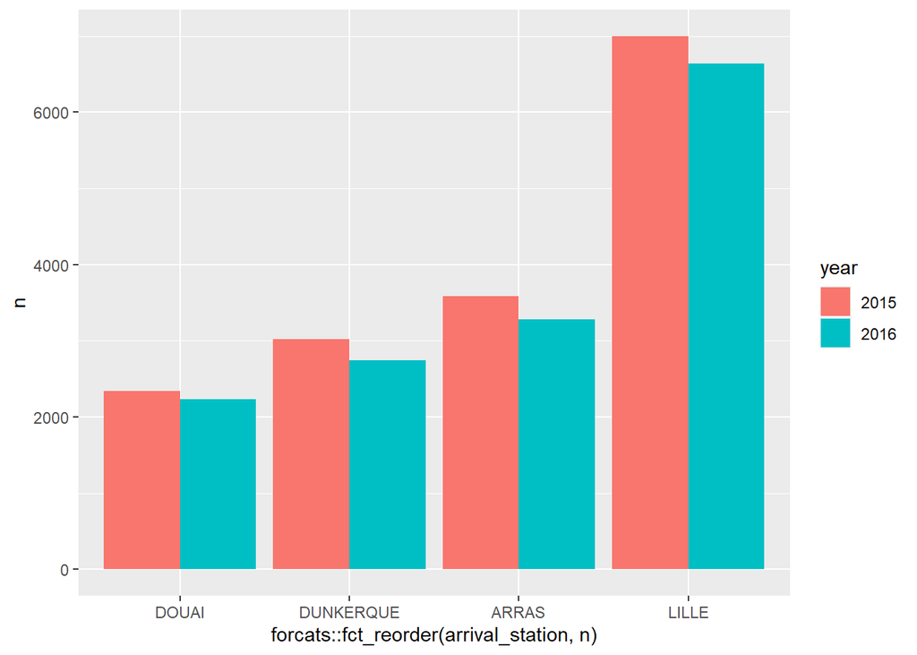

```r
multi_bar_plot <- data |>
  filter(departure_station == "PARIS NORD",
         year %in% c(2015, 2016)) |>
  mutate(year = as.character(year)) |>
  group_by(year, arrival_station) |>
  summarise(n = sum(total_num_trips), .groups = "drop") |>
  ggplot(aes(x = forcats::fct_reorder(arrival_station, n), y = n, fill = year)) +
  geom_bar(stat="identity", position = "dodge")

multi_bar_plot
```

## 📚 Extra resources

- [Exploring RStudio’s Visual Markdown Editor - Posit](https://posit.co/blog/exploring-rstudio-visual-markdown-editor/)